# tidyverse で処理

(初回だけ)パッケージのインストール

パッケージの読み込み

```r
#パッケージの読み込み
library("tidyverse")
library("magrittr")
```

```
─ Attaching packages ──────────────────────────────────────────────── tidyverse 1.2.1 ─
─ Conflicts ───────────────────────────────────────────────── tidyverse_conflicts() ─
```

だそうな。

データ読み込み ファイル名指定

```r
# データ読み込み ファイル名指定
f <-
  read_csv(
    'data-sakata-ymd-10-88-18.csv',
    col_names = FALSE,
    skip = 1,
    locale = locale(encoding = "cp932")
  )
f %>% head(6L)
```

| X1 | X2 | X3 | X4 | X5 | X6 | X7 | X8 | X9 | X10 | X11 | X12 | X13 | X14 | X15 | X16 | X17 | X18 | X19 | X20 | X21 | X22 | X23 | X24 | X25 | X26 | X27 | X28 | X29 | X30 | … |
| --- | --- | --- | --- | --- | --- | --- | --- | --- | --- | --- | --- | --- | --- | --- | --- | --- | --- | --- | --- | --- | --- | --- | --- | --- | --- | --- | --- | --- | --- | --- |
| 集計開始 | NA | NA | 集計終了 | NA | NA | 酒田 | 酒田 | 酒田 | 酒田 | 酒田 | 酒田 | 酒田 | 酒田 | 酒田 | 酒田 | 酒田 | 酒田 | 酒田 | 酒田 | 酒田 | 酒田 | 酒田 | 酒田 | 酒田 | 酒田 | 酒田 | 酒田 | 酒田 | 酒田 | … |
| 年 | 月 | 日 | 年 | 月 | 日 | 日照時間(時間) | 日照時間(時間) | 日照時間(時間) | 日照時間(時間) | 最高気温(℃) | 最高気温(℃) | 最高気温(℃) | 最低気温(℃) | 最低気温(℃) | 最低気温(℃) | 平均気温(℃) | 平均気温(℃) | 平均気温(℃) | 日最低気温の平均(℃) | 日最低気温の平均(℃) | 日最低気温の平均(℃) | 日最高気温の平均(℃) | 日最高気温の平均(℃) | 日最高気温の平均(℃) | 降水量の合計(mm) | 降水量の合計(mm) | 降水量の合計(mm) | 降水量の合計(mm) | 日降水量の最大(mm) | … |
| NA | NA | NA | NA | NA | NA | NA | NA | NA | NA | NA | NA | NA | NA | NA | NA | NA | NA | NA | NA | NA | NA | NA | NA | NA | NA | NA | NA | NA | NA | … |
| NA | NA | NA | NA | NA | NA | NA | 現象なし情報 | 品質情報 | 均質番号 | NA | 品質情報 | 均質番号 | NA | 品質情報 | 均質番号 | NA | 品質情報 | 均質番号 | NA | 品質情報 | 均質番号 | NA | 品質情報 | 均質番号 | NA | 現象なし情報 | 品質情報 | 均質番号 | NA | … |
| 1988 | 1 | 1 | 1988 | 1 | 10 | 14.6 | 0 | 8 | 1 | 9.0 | 8 | 1 | -2.8 | 8 | 1 | 2.5 | 8 | 1 | -0.2 | 8 | 1 | 5.5 | 8 | 1 | 69.5 | 0 | 8 | 1 | 17.5 | … |
| 1988 | 1 | 11 | 1988 | 1 | 20 | 15.1 | 0 | 8 | 1 | 11.0 | 8 | 1 | -3.0 | 8 | 1 | 3.1 | 8 | 1 | -0.4 | 8 | 1 | 6.3 | 8 | 1 | 27.0 | 0 | 8 | 1 | 7.0 | … |

空行削除。

```r
f %<>% filter(rowSums(is.na(.)) != ncol(.))
```

方針決める。

実際のデータの行と，項目名の行を分ける。

要は項目名に相当する行が何行目までか，データが何行目からか。

データの行は，基本数字（かNA）が入ってるはず。数字に変換してみる。

```r
sapply(f[,1], as.numeric) %>% head(8)
```

```
 強制変換により NA が生成されました
```

```
       X1
[1,]   NA
[2,]   NA
[3,]   NA
[4,] 1988
[5,] 1988
[6,] 1988
[7,] 1988
[8,] 1988
```

同じことを purrr で。

```r
f[,1] %>% purrr::map(as.numeric) %>% head(8)
```

```
 強制変換により NA が生成されました
```

```
$X1
   [1]   NA   NA   NA 1988 1988 1988 1988 1988 1988 1988 1988 1988 1988 1988 1988 1988 1988 1988 1988 1988 1988 1988 1988
  [24] 1988 1988 1988 1988 1988 1988 1988 1988 1988 1988 1988 1988 1988 1988 1988 1988 1989 1989 1989 1989 1989 1989 1989
  [47] 1989 1989 1989 1989 1989 1989 1989 1989 1989 1989 1989 1989 1989 1989 1989 1989 1989 1989 1989 1989 1989 1989 1989
  [70] 1989 1989 1989 1989 1989 1989 1990 1990 1990 1990 1990 1990 1990 1990 1990 1990 1990 1990 1990 1990 1990 1990 1990
  [93] 1990 1990 1990 1990 1990 1990 1990 1990 1990 1990 1990 1990 1990 1990 1990 1990 1990 1990 1990 1991 1991 1991 1991
 [116] 1991 1991 1991 1991 1991 1991 1991 1991 1991 1991 1991 1991 1991 1991 1991 1991 1991 1991 1991 1991 1991 1991 1991
 [139] 1991 1991 1991 1991 1991 1991 1991 1991 1991 1992 1992 1992 1992 1992 1992 1992 1992 1992 1992 1992 1992 1992 1992
 [162] 1992 1992 1992 1992 1992 1992 1992 1992 1992 1992 1992 1992 1992 1992 1992 1992 1992 1992 1992 1992 1992 1992 1993
 [185] 1993 1993 1993 1993 1993 1993 1993 1993 1993 1993 1993 1993 1993 1993 1993 1993 1993 1993 1993 1993 1993 1993 1993
 [208] 1993 1993 1993 1993 1993 1993 1993 1993 1993 1993 1993 1993 1994 1994 1994 1994 1994 1994 1994 1994 1994 1994 1994
 [231] 1994 1994 1994 1994 1994 1994 1994 1994 1994 1994 1994 1994 1994 1994 1994 1994 1994 1994 1994 1994 1994 1994 1994
 [254] 1994 1994 1995 1995 1995 1995 1995 1995 1995 1995 1995 1995 1995 1995 1995 1995 1995 1995 1995 1995 1995 1995 1995
 [277] 1995 1995 1995 1995 1995 1995 1995 1995 1995 1995 1995 1995 1995 1995 1995 1996 1996 1996 1996 1996 1996 1996 1996
 [300] 1996 1996 1996 1996 1996 1996 1996 1996 1996 1996 1996 1996 1996 1996 1996 1996 1996 1996 1996 1996 1996 1996 1996
```

[output cut: 31 more lines]

…

```r
f[,1] %>% map(as.numeric) %>% str
```

```
 強制変換により NA が生成されました
```

```
List of 1
 $ X1: num [1:1116] NA NA NA 1988 1988 ...
```

リストか。

```r
f[,1] %>% purrr::map(as.numeric) %>% flatten_dbl %>% head(8)
```

```
 強制変換により NA が生成されました
```

```
[1]   NA   NA   NA 1988 1988 1988 1988 1988
```

先頭から“NA”が続く最後の行までが項目名。その後のちゃんと数字が始まる（NA じゃない）行からがデータ。

as.numeric が NA に「ならない」（つまり数字）行は…

```r
f[,1] %>% purrr::map(as.numeric) %>% map({~ !is.na(.)}) %>% flatten_lgl %>% head(8)
```

```
 強制変換により NA が生成されました
```

```
[1] FALSE FALSE FALSE  TRUE  TRUE  TRUE  TRUE  TRUE
```

TRUE になる一番始めの行，つまりデータの始まる行は…

```r
f[,1] %>% purrr::map(as.numeric) %>% map({~ !is.na(.)}) %>% flatten_lgl %>% which %>% min
```

```
 強制変換により NA が生成されました
```

```
[1] 4
```

ということで，この行まではヘッダ用としてとっといてから削除。

```r
# ヘッダ用の行の最後
header_row_end <- (f[,1] %>% purrr::map(as.numeric) %>% map({~ !is.na(.)}) %>% flatten_lgl %>% which %>% min)-1
```

```
 強制変換により NA が生成されました
```

```r
header_row_end
```

```
[1] 3
```

```r
# ヘッダ用の行
header_row <- f %>% slice(1:header_row_end)
# header_row <- f[1:header_row_end,]
header_row
```

| X1 | X2 | X3 | X4 | X5 | X6 | X7 | X8 | X9 | X10 | X11 | X12 | X13 | X14 | X15 | X16 | X17 | X18 | X19 | X20 | X21 | X22 | X23 | X24 | X25 | X26 | X27 | X28 | X29 | X30 | … |
| --- | --- | --- | --- | --- | --- | --- | --- | --- | --- | --- | --- | --- | --- | --- | --- | --- | --- | --- | --- | --- | --- | --- | --- | --- | --- | --- | --- | --- | --- | --- |
| 集計開始 | NA | NA | 集計終了 | NA | NA | 酒田 | 酒田 | 酒田 | 酒田 | 酒田 | 酒田 | 酒田 | 酒田 | 酒田 | 酒田 | 酒田 | 酒田 | 酒田 | 酒田 | 酒田 | 酒田 | 酒田 | 酒田 | 酒田 | 酒田 | 酒田 | 酒田 | 酒田 | 酒田 | … |
| 年 | 月 | 日 | 年 | 月 | 日 | 日照時間(時間) | 日照時間(時間) | 日照時間(時間) | 日照時間(時間) | 最高気温(℃) | 最高気温(℃) | 最高気温(℃) | 最低気温(℃) | 最低気温(℃) | 最低気温(℃) | 平均気温(℃) | 平均気温(℃) | 平均気温(℃) | 日最低気温の平均(℃) | 日最低気温の平均(℃) | 日最低気温の平均(℃) | 日最高気温の平均(℃) | 日最高気温の平均(℃) | 日最高気温の平均(℃) | 降水量の合計(mm) | 降水量の合計(mm) | 降水量の合計(mm) | 降水量の合計(mm) | 日降水量の最大(mm) | … |
| NA | NA | NA | NA | NA | NA | NA | 現象なし情報 | 品質情報 | 均質番号 | NA | 品質情報 | 均質番号 | NA | 品質情報 | 均質番号 | NA | 品質情報 | 均質番号 | NA | 品質情報 | 均質番号 | NA | 品質情報 | 均質番号 | NA | 現象なし情報 | 品質情報 | 均質番号 | NA | … |

```r
# ヘッダ用の行を削除した残りが，データ用
f %>% slice(-c(1:header_row_end))
```

| X1 | X2 | X3 | X4 | X5 | X6 | X7 | X8 | X9 | X10 | X11 | X12 | X13 | X14 | X15 | X16 | X17 | X18 | X19 | X20 | X21 | X22 | X23 | X24 | X25 | X26 | X27 | X28 | X29 | X30 | … |
| --- | --- | --- | --- | --- | --- | --- | --- | --- | --- | --- | --- | --- | --- | --- | --- | --- | --- | --- | --- | --- | --- | --- | --- | --- | --- | --- | --- | --- | --- | --- |
| 1988 | 1 | 1 | 1988 | 1 | 10 | 14.6 | 0 | 8 | 1 | 9.0 | 8 | 1 | -2.8 | 8 | 1 | 2.5 | 8 | 1 | -0.2 | 8 | 1 | 5.5 | 8 | 1 | 69.5 | 0 | 8 | 1 | 17.5 | … |
| 1988 | 1 | 11 | 1988 | 1 | 20 | 15.1 | 0 | 8 | 1 | 11.0 | 8 | 1 | -3.0 | 8 | 1 | 3.1 | 8 | 1 | -0.4 | 8 | 1 | 6.3 | 8 | 1 | 27.0 | 0 | 8 | 1 | 7.0 | … |
| 1988 | 1 | 21 | 1988 | 1 | 31 | 6.4 | 0 | 8 | 1 | 14.8 | 8 | 1 | -2.7 | 8 | 1 | 2.0 | 8 | 1 | -0.5 | 8 | 1 | 4.7 | 8 | 1 | 95.5 | 0 | 8 | 1 | 27.5 | … |
| 1988 | 2 | 1 | 1988 | 2 | 10 | 11.7 | 0 | 8 | 1 | 9.2 | 8 | 1 | -6.2 | 8 | 1 | -0.4 | 8 | 1 | -3.3 | 8 | 1 | 2.7 | 8 | 1 | 62.5 | 0 | 8 | 1 | 24.5 | … |
| 1988 | 2 | 11 | 1988 | 2 | 20 | 17.0 | 0 | 8 | 1 | 3.7 | 8 | 1 | -6.0 | 8 | 1 | -1.0 | 8 | 1 | -3.3 | 8 | 1 | 1.4 | 8 | 1 | 19.0 | 0 | 8 | 1 | 3.5 | … |
| 1988 | 2 | 21 | 1988 | 2 | 29 | 29.1 | 0 | 8 | 1 | 5.0 | 8 | 1 | -5.5 | 8 | 1 | 0.4 | 8 | 1 | -1.8 | 8 | 1 | 2.9 | 8 | 1 | 17.5 | 0 | 8 | 1 | 7.5 | … |
| 1988 | 3 | 1 | 1988 | 3 | 10 | 20.0 | 0 | 8 | 1 | 6.2 | 8 | 1 | -4.9 | 8 | 1 | 1.3 | 8 | 1 | -1.7 | 8 | 1 | 4.1 | 8 | 1 | 40.0 | 0 | 8 | 1 | 9.0 | … |
| 1988 | 3 | 11 | 1988 | 3 | 20 | 31.3 | 0 | 8 | 1 | 15.5 | 8 | 1 | -4.9 | 8 | 1 | 4.7 | 8 | 1 | 0.2 | 8 | 1 | 9.0 | 8 | 1 | 26.5 | 0 | 8 | 1 | 10.5 | … |
| 1988 | 3 | 21 | 1988 | 3 | 31 | 60.3 | 0 | 8 | 1 | 11.5 | 8 | 1 | -1.2 | 8 | 1 | 5.0 | 8 | 1 | 1.0 | 8 | 1 | 8.9 | 8 | 1 | 9.5 | 0 | 8 | 1 | 6.0 | … |
| 1988 | 4 | 1 | 1988 | 4 | 10 | 65.0 | 0 | 5 | 1 | 16.0 | 8 | 1 | -1.7 | 8 | 1 | 6.1 | 8 | 1 | 1.3 | 8 | 1 | 11.0 | 8 | 1 | 14.0 | 0 | 8 | 1 | 8.0 | … |

[output cut: 990 more lines]

年月日を表す列を決める。 まず先頭行。

```r
header_row %>% slice(1)
```

| X1 | X2 | X3 | X4 | X5 | X6 | X7 | X8 | X9 | X10 | X11 | X12 | X13 | X14 | X15 | X16 | X17 | X18 | X19 | X20 | X21 | X22 | X23 | X24 | X25 | X26 | X27 | X28 | X29 | X30 | … |
| --- | --- | --- | --- | --- | --- | --- | --- | --- | --- | --- | --- | --- | --- | --- | --- | --- | --- | --- | --- | --- | --- | --- | --- | --- | --- | --- | --- | --- | --- | --- |
| 集計開始 | NA | NA | 集計終了 | NA | NA | 酒田 | 酒田 | 酒田 | 酒田 | 酒田 | 酒田 | 酒田 | 酒田 | 酒田 | 酒田 | 酒田 | 酒田 | 酒田 | 酒田 | 酒田 | 酒田 | 酒田 | 酒田 | 酒田 | 酒田 | 酒田 | 酒田 | 酒田 | 酒田 | … |

各項目が「集計開始」「集計終了」NA など「以外」（つまり地名）かどうか。

```r
ymd_col_names = c("集計開始", "集計終了")
is_ymd_row <- function(x, col_names) {
  result <- !(x %in% col_names) && !is.na(x)
  return(result)
}
sapply(header_row, is_ymd_row, ymd_col_names)
```

```
   X1    X2    X3    X4    X5    X6    X7    X8    X9   X10   X11   X12   X13   X14   X15   X16   X17   X18   X19   X20
FALSE FALSE FALSE FALSE FALSE FALSE  TRUE  TRUE  TRUE  TRUE  TRUE  TRUE  TRUE  TRUE  TRUE  TRUE  TRUE  TRUE  TRUE  TRUE
  X21   X22   X23   X24   X25   X26   X27   X28   X29   X30   X31   X32   X33
 TRUE  TRUE  TRUE  TRUE  TRUE  TRUE  TRUE  TRUE  TRUE  TRUE  TRUE  TRUE  TRUE
```

年月日の列の最後は，地名が始まる一番最初の列の，1つ前

```r
ymd_col_end <- (sapply(header_row, is_ymd_row, ymd_col_names) %>% which %>% min) -1
ymd_col_end
```

```
[1] 6
```

というわけで，年月日の列。

```r
f %>% dplyr::select(c(1:ymd_col_end))
```

| X1 | X2 | X3 | X4 | X5 | X6 |
| --- | --- | --- | --- | --- | --- |
| 集計開始 | NA | NA | 集計終了 | NA | NA |
| 年 | 月 | 日 | 年 | 月 | 日 |
| NA | NA | NA | NA | NA | NA |
| 1988 | 1 | 1 | 1988 | 1 | 10 |
| 1988 | 1 | 11 | 1988 | 1 | 20 |
| 1988 | 1 | 21 | 1988 | 1 | 31 |
| 1988 | 2 | 1 | 1988 | 2 | 10 |
| 1988 | 2 | 11 | 1988 | 2 | 20 |
| 1988 | 2 | 21 | 1988 | 2 | 29 |
| 1988 | 3 | 1 | 1988 | 3 | 10 |

[output cut: 990 more lines]

ちなみに年月日のヘッダ部分。

```r
f %>% dplyr::select(c(1:ymd_col_end)) %>% slice(1:header_row_end)
```

| X1 | X2 | X3 | X4 | X5 | X6 |
| --- | --- | --- | --- | --- | --- |
| 集計開始 | NA | NA | 集計終了 | NA | NA |
| 年 | 月 | 日 | 年 | 月 | 日 |
| NA | NA | NA | NA | NA | NA |

年月日データ部分。

```r
f %>% dplyr::select(c(1:ymd_col_end)) %>% slice(-c(1:header_row_end)) %>% head(6)
```

| X1 | X2 | X3 | X4 | X5 | X6 |
| --- | --- | --- | --- | --- | --- |
| 1988 | 1 | 1 | 1988 | 1 | 10 |
| 1988 | 1 | 11 | 1988 | 1 | 20 |
| 1988 | 1 | 21 | 1988 | 1 | 31 |
| 1988 | 2 | 1 | 1988 | 2 | 10 |
| 1988 | 2 | 11 | 1988 | 2 | 20 |
| 1988 | 2 | 21 | 1988 | 2 | 29 |

```r
f %>% dplyr::select(c(1:ymd_col_end))
```

| X1 | X2 | X3 | X4 | X5 | X6 |
| --- | --- | --- | --- | --- | --- |
| 集計開始 | NA | NA | 集計終了 | NA | NA |
| 年 | 月 | 日 | 年 | 月 | 日 |
| NA | NA | NA | NA | NA | NA |
| 1988 | 1 | 1 | 1988 | 1 | 10 |
| 1988 | 1 | 11 | 1988 | 1 | 20 |
| 1988 | 1 | 21 | 1988 | 1 | 31 |
| 1988 | 2 | 1 | 1988 | 2 | 10 |
| 1988 | 2 | 11 | 1988 | 2 | 20 |
| 1988 | 2 | 21 | 1988 | 2 | 29 |
| 1988 | 3 | 1 | 1988 | 3 | 10 |

[output cut: 990 more lines]

気象データのヘッダ。

```r
f %>% dplyr::select(-c(1:ymd_col_end)) %>% slice(1:header_row_end)
```

| X7 | X8 | X9 | X10 | X11 | X12 | X13 | X14 | X15 | X16 | X17 | X18 | X19 | X20 | X21 | X22 | X23 | X24 | X25 | X26 | X27 | X28 | X29 | X30 | X31 | X32 | X33 |
| --- | --- | --- | --- | --- | --- | --- | --- | --- | --- | --- | --- | --- | --- | --- | --- | --- | --- | --- | --- | --- | --- | --- | --- | --- | --- | --- |
| 酒田 | 酒田 | 酒田 | 酒田 | 酒田 | 酒田 | 酒田 | 酒田 | 酒田 | 酒田 | 酒田 | 酒田 | 酒田 | 酒田 | 酒田 | 酒田 | 酒田 | 酒田 | 酒田 | 酒田 | 酒田 | 酒田 | 酒田 | 酒田 | 酒田 | 酒田 | 酒田 |
| 日照時間(時間) | 日照時間(時間) | 日照時間(時間) | 日照時間(時間) | 最高気温(℃) | 最高気温(℃) | 最高気温(℃) | 最低気温(℃) | 最低気温(℃) | 最低気温(℃) | 平均気温(℃) | 平均気温(℃) | 平均気温(℃) | 日最低気温の平均(℃) | 日最低気温の平均(℃) | 日最低気温の平均(℃) | 日最高気温の平均(℃) | 日最高気温の平均(℃) | 日最高気温の平均(℃) | 降水量の合計(mm) | 降水量の合計(mm) | 降水量の合計(mm) | 降水量の合計(mm) | 日降水量の最大(mm) | 日降水量の最大(mm) | 日降水量の最大(mm) | 日降水量の最大(mm) |
| NA | 現象なし情報 | 品質情報 | 均質番号 | NA | 品質情報 | 均質番号 | NA | 品質情報 | 均質番号 | NA | 品質情報 | 均質番号 | NA | 品質情報 | 均質番号 | NA | 品質情報 | 均質番号 | NA | 現象なし情報 | 品質情報 | 均質番号 | NA | 現象なし情報 | 品質情報 | 均質番号 |

気象の実データ部分。

```r
f %>% dplyr::select(-c(1:ymd_col_end)) %>% slice(-c(1:header_row_end)) %>% head(6)
```

| X7 | X8 | X9 | X10 | X11 | X12 | X13 | X14 | X15 | X16 | X17 | X18 | X19 | X20 | X21 | X22 | X23 | X24 | X25 | X26 | X27 | X28 | X29 | X30 | X31 | X32 | X33 |
| --- | --- | --- | --- | --- | --- | --- | --- | --- | --- | --- | --- | --- | --- | --- | --- | --- | --- | --- | --- | --- | --- | --- | --- | --- | --- | --- |
| 14.6 | 0 | 8 | 1 | 9.0 | 8 | 1 | -2.8 | 8 | 1 | 2.5 | 8 | 1 | -0.2 | 8 | 1 | 5.5 | 8 | 1 | 69.5 | 0 | 8 | 1 | 17.5 | 0 | 8 | 1 |
| 15.1 | 0 | 8 | 1 | 11.0 | 8 | 1 | -3.0 | 8 | 1 | 3.1 | 8 | 1 | -0.4 | 8 | 1 | 6.3 | 8 | 1 | 27.0 | 0 | 8 | 1 | 7.0 | 0 | 8 | 1 |
| 6.4 | 0 | 8 | 1 | 14.8 | 8 | 1 | -2.7 | 8 | 1 | 2.0 | 8 | 1 | -0.5 | 8 | 1 | 4.7 | 8 | 1 | 95.5 | 0 | 8 | 1 | 27.5 | 0 | 8 | 1 |
| 11.7 | 0 | 8 | 1 | 9.2 | 8 | 1 | -6.2 | 8 | 1 | -0.4 | 8 | 1 | -3.3 | 8 | 1 | 2.7 | 8 | 1 | 62.5 | 0 | 8 | 1 | 24.5 | 0 | 8 | 1 |
| 17.0 | 0 | 8 | 1 | 3.7 | 8 | 1 | -6.0 | 8 | 1 | -1.0 | 8 | 1 | -3.3 | 8 | 1 | 1.4 | 8 | 1 | 19.0 | 0 | 8 | 1 | 3.5 | 0 | 8 | 1 |
| 29.1 | 0 | 8 | 1 | 5.0 | 8 | 1 | -5.5 | 8 | 1 | 0.4 | 8 | 1 | -1.8 | 8 | 1 | 2.9 | 8 | 1 | 17.5 | 0 | 8 | 1 | 7.5 | 0 | 8 | 1 |

ここまでのまとめ。

```r
# データ読み込み
data_file = 'data-sakata-ymd-10-88-18.csv'
ymd_col_names = c("集計開始", "集計終了")
read_jma <- function(csv_f) {
  f <-
    read_csv(
      data_file
      , col_names = FALSE
      , skip = 1
      , locale = locale(encoding = "cp932")
    )
# 空行削除
  return(f %>% filter(rowSums(is.na(.)) != ncol(.)))
}
# ヘッダとして扱うのは何行目までか
header_row_end <- function(tbl) {
  result <- (tbl[,1] %>% purrr::map(as.numeric) %>% map({~ !is.na(.)}) %>% flatten_lgl %>% which %>% min)-1
  return(result)
}
# ヘッダの行
header_rows <- function(tbl, hd_num) {
  return(tbl %>% slice(c(1:hd_num)))
}
# データの行
data_rows <- function(tbl, row_num) {
  return(tbl %>% slice(-c(1:row_num)))
}
# 年月日は何列目までか
# header_row <- f %>% slice(1:header_row_end)
is_ymd_row <- function(x, col_names) {
  result <- !(x %in% col_names) && !is.na(x)
  return(result)
}
ymd_col_end <- function(tbl, col_names) {
  (sapply(tbl[1,], is_ymd_row, col_names) %>% which %>% min) -1
}
# ymdの列
ymd_cols <- function(tbl, col_num) {
  return(tbl %>% dplyr::select(c(1:col_num)))
}
clm_cols <- function(tbl, col_num) {
  return(tbl %>% dplyr::select(-c(1:col_num)))
}
data_tbl <- read_jma(data_file)
# ヘッダ行
headers_end <- data_tbl %>% header_row_end
```

```
 強制変換により NA が生成されました
```

```r
# 年月日列
ymd_end <- data_tbl %>% ymd_col_end(ymd_col_names)
# data_tbl %>% ymd_cols(ymd_end) %>% header_rows(headers_end)
# data_tbl %>% ymd_cols(ymd_end) %>% data_rows(headers_end)
# data_tbl %>% clm_cols(ymd_end) %>% header_rows(headers_end)
# data_tbl %>% clm_cols(ymd_end) %>% data_rows(headers_end)
```

さて，ヘッダとしてとっといたとこから，列名作る。

まず年月日。

「集計開始」「集計終了」が入ってない列を穴埋め。

一度転置してから下方向に補完して，元に戻す。

```r
ymd_headers_tbl <- data_tbl %>% ymd_cols(ymd_end) %>% header_rows(headers_end)
# ymd_headers_tbl
ymd_headers_tbl[1,] %<>% t %>% as.data.frame() %>% tidyr::fill(1) %>% t
ymd_headers_tbl
```

| X1 | X2 | X3 | X4 | X5 | X6 |
| --- | --- | --- | --- | --- | --- |
| 集計開始 | 集計開始 | 集計開始 | 集計終了 | 集計終了 | 集計終了 |
| 年 | 月 | 日 | 年 | 月 | 日 |
| NA | NA | NA | NA | NA | NA |

1行目が「集計開始」=> start,「集計終了」=> end，2行目「年」=> y,「月」=> m,「日」=> d に変換，くっつけて列名に。

```r
start_end_vec <- c("集計開始" = "start", "集計終了" = "end")
ymd_vec <- c("年" = "y", "月" = "m", "日" = "d")
make_ymd_rowname <- function(dt, vec1, vec2) {
  result1 <- vec1[dt[1]]
  result2 <- vec2[dt[2]]
  result <- paste(result1, result2, sep="_")
  return(result)
}
ymd_col_name <- apply(ymd_headers_tbl, 2, make_ymd_rowname, start_end_vec, ymd_vec)
ymd_col_name
```

```
       X1        X2        X3        X4        X5        X6
"start_y" "start_m" "start_d"   "end_y"   "end_m"   "end_d"
```

年月日のデータに，列名つける。

```r
ymd_data_tbl <- data_tbl %>% ymd_cols(ymd_end) %>% data_rows(headers_end)
names(ymd_data_tbl) <- ymd_col_name
ymd_data_tbl
```

| start_y | start_m | start_d | end_y | end_m | end_d |
| --- | --- | --- | --- | --- | --- |
| 1988 | 1 | 1 | 1988 | 1 | 10 |
| 1988 | 1 | 11 | 1988 | 1 | 20 |
| 1988 | 1 | 21 | 1988 | 1 | 31 |
| 1988 | 2 | 1 | 1988 | 2 | 10 |
| 1988 | 2 | 11 | 1988 | 2 | 20 |
| 1988 | 2 | 21 | 1988 | 2 | 29 |
| 1988 | 3 | 1 | 1988 | 3 | 10 |
| 1988 | 3 | 11 | 1988 | 3 | 20 |
| 1988 | 3 | 21 | 1988 | 3 | 31 |
| 1988 | 4 | 1 | 1988 | 4 | 10 |

[output cut: 990 more lines]

気象データの列名。まずヘッダは…

```r
clm_headers_tbl <- data_tbl %>% clm_cols(ymd_end) %>% header_rows(headers_end)
clm_headers_tbl
```

| X7 | X8 | X9 | X10 | X11 | X12 | X13 | X14 | X15 | X16 | X17 | X18 | X19 | X20 | X21 | X22 | X23 | X24 | X25 | X26 | X27 | X28 | X29 | X30 | X31 | X32 | X33 |
| --- | --- | --- | --- | --- | --- | --- | --- | --- | --- | --- | --- | --- | --- | --- | --- | --- | --- | --- | --- | --- | --- | --- | --- | --- | --- | --- |
| 酒田 | 酒田 | 酒田 | 酒田 | 酒田 | 酒田 | 酒田 | 酒田 | 酒田 | 酒田 | 酒田 | 酒田 | 酒田 | 酒田 | 酒田 | 酒田 | 酒田 | 酒田 | 酒田 | 酒田 | 酒田 | 酒田 | 酒田 | 酒田 | 酒田 | 酒田 | 酒田 |
| 日照時間(時間) | 日照時間(時間) | 日照時間(時間) | 日照時間(時間) | 最高気温(℃) | 最高気温(℃) | 最高気温(℃) | 最低気温(℃) | 最低気温(℃) | 最低気温(℃) | 平均気温(℃) | 平均気温(℃) | 平均気温(℃) | 日最低気温の平均(℃) | 日最低気温の平均(℃) | 日最低気温の平均(℃) | 日最高気温の平均(℃) | 日最高気温の平均(℃) | 日最高気温の平均(℃) | 降水量の合計(mm) | 降水量の合計(mm) | 降水量の合計(mm) | 降水量の合計(mm) | 日降水量の最大(mm) | 日降水量の最大(mm) | 日降水量の最大(mm) | 日降水量の最大(mm) |
| NA | 現象なし情報 | 品質情報 | 均質番号 | NA | 品質情報 | 均質番号 | NA | 品質情報 | 均質番号 | NA | 品質情報 | 均質番号 | NA | 品質情報 | 均質番号 | NA | 品質情報 | 均質番号 | NA | 現象なし情報 | 品質情報 | 均質番号 | NA | 現象なし情報 | 品質情報 | 均質番号 |

2行目と3行目くっつけて列名に。

```r
make_clm_rowname <- function(dt) {
  result1 <- dt[2]
  result2 <- dt[3]
  result <- paste(result1, result2, sep="_")
  return(result)
}
clm_col_name <- apply(clm_headers_tbl, 2, make_clm_rowname)
clm_col_name
```

```
                               X7                                X8                                X9
              "日照時間(時間)_NA"     "日照時間(時間)_現象なし情報"         "日照時間(時間)_品質情報"
                              X10                               X11                               X12
        "日照時間(時間)_均質番号"                 "最高気温(℃)_NA"           "最高気温(℃)_品質情報"
                              X13                               X14                               X15
          "最高気温(℃)_均質番号"                 "最低気温(℃)_NA"           "最低気温(℃)_品質情報"
                              X16                               X17                               X18
          "最低気温(℃)_均質番号"                 "平均気温(℃)_NA"           "平均気温(℃)_品質情報"
                              X19                               X20                               X21
          "平均気温(℃)_均質番号"         "日最低気温の平均(℃)_NA"   "日最低気温の平均(℃)_品質情報"
                              X22                               X23                               X24
  "日最低気温の平均(℃)_均質番号"         "日最高気温の平均(℃)_NA"   "日最高気温の平均(℃)_品質情報"
                              X25                               X26                               X27
  "日最高気温の平均(℃)_均質番号"             "降水量の合計(mm)_NA"   "降水量の合計(mm)_現象なし情報"
                              X28                               X29                               X30
      "降水量の合計(mm)_品質情報"       "降水量の合計(mm)_均質番号"           "日降水量の最大(mm)_NA"
                              X31                               X32                               X33
"日降水量の最大(mm)_現象なし情報"     "日降水量の最大(mm)_品質情報"     "日降水量の最大(mm)_均質番号"
```

…「_NA」はいらんな。

```r
make_clm_rowname <- function(dt) {
  result1 <- dt[2]
  result2 <- dt[3]
  result_vec <- c(result1, result2)
# result_vec から，NAではない要素を，"_"で連結して返す
  result <- paste(result_vec[!is.na(result_vec)], collapse="_")
  return(result)
}
clm_col_name <- apply(clm_headers_tbl, 2, make_clm_rowname)
clm_col_name
```

```
                               X7                                X8                                X9
                 "日照時間(時間)"     "日照時間(時間)_現象なし情報"         "日照時間(時間)_品質情報"
                              X10                               X11                               X12
        "日照時間(時間)_均質番号"                    "最高気温(℃)"           "最高気温(℃)_品質情報"
                              X13                               X14                               X15
          "最高気温(℃)_均質番号"                    "最低気温(℃)"           "最低気温(℃)_品質情報"
                              X16                               X17                               X18
          "最低気温(℃)_均質番号"                    "平均気温(℃)"           "平均気温(℃)_品質情報"
                              X19                               X20                               X21
          "平均気温(℃)_均質番号"            "日最低気温の平均(℃)"   "日最低気温の平均(℃)_品質情報"
                              X22                               X23                               X24
  "日最低気温の平均(℃)_均質番号"            "日最高気温の平均(℃)"   "日最高気温の平均(℃)_品質情報"
                              X25                               X26                               X27
  "日最高気温の平均(℃)_均質番号"                "降水量の合計(mm)"   "降水量の合計(mm)_現象なし情報"
                              X28                               X29                               X30
      "降水量の合計(mm)_品質情報"       "降水量の合計(mm)_均質番号"              "日降水量の最大(mm)"
                              X31                               X32                               X33
"日降水量の最大(mm)_現象なし情報"     "日降水量の最大(mm)_品質情報"     "日降水量の最大(mm)_均質番号"
```

2行目の「(時間)」「(℃)」「(mm)」「の平均」「の合計」，3行目の「番号」「情報」なんかもジャマ。

```r
rmv_str_1 <- function(str) {
  result <- str %>% sub("の.+", "", .) %>% sub("\\(.+", "", .)
  return(result)
}
rmv_str_2 <- function(str) {
  result <- str %>% sub("情報", "", .) %>% sub("番号", "", .)
  return(result)
}
make_clm_rowname <- function(dt) {
  result1 <- rmv_str_1(dt[2])
  result2 <- rmv_str_2(dt[3])
  result_vec <- c(result1, result2)
# result_vec から，NAではない要素を，"_"で連結して返す
  result <- paste(result_vec[!is.na(result_vec)], collapse="_")
  return(result)
}
clm_col_name <- apply(clm_headers_tbl, 2, make_clm_rowname)
clm_col_name
```

```
                 X7                  X8                  X9                 X10                 X11                 X12
         "日照時間" "日照時間_現象なし"     "日照時間_品質"     "日照時間_均質"          "最高気温"     "最高気温_品質"
                X13                 X14                 X15                 X16                 X17                 X18
    "最高気温_均質"          "最低気温"     "最低気温_品質"     "最低気温_均質"          "平均気温"     "平均気温_品質"
                X19                 X20                 X21                 X22                 X23                 X24
    "平均気温_均質"        "日最低気温"   "日最低気温_品質"   "日最低気温_均質"        "日最高気温"   "日最高気温_品質"
                X25                 X26                 X27                 X28                 X29                 X30
  "日最高気温_均質"            "降水量"   "降水量_現象なし"       "降水量_品質"       "降水量_均質"          "日降水量"
                X31                 X32                 X33
"日降水量_現象なし"     "日降水量_品質"     "日降水量_均質"
```

列名つける。

```r
clm_data_tbl <- data_tbl %>% clm_cols(ymd_end) %>% data_rows(headers_end)
names(clm_data_tbl) <- clm_col_name
clm_data_tbl
```

| 日照時間 | 日照時間_現象なし | 日照時間_品質 | 日照時間_均質 | 最高気温 | 最高気温_品質 | 最高気温_均質 | 最低気温 | 最低気温_品質 | 最低気温_均質 | 平均気温 | 平均気温_品質 | 平均気温_均質 | 日最低気温 | 日最低気温_品質 | 日最低気温_均質 | 日最高気温 | 日最高気温_品質 | 日最高気温_均質 | 降水量 | 降水量_現象なし | 降水量_品質 | 降水量_均質 | 日降水量 | 日降水量_現象なし | 日降水量_品質 | 日降水量_均質 |
| --- | --- | --- | --- | --- | --- | --- | --- | --- | --- | --- | --- | --- | --- | --- | --- | --- | --- | --- | --- | --- | --- | --- | --- | --- | --- | --- |
| 14.6 | 0 | 8 | 1 | 9.0 | 8 | 1 | -2.8 | 8 | 1 | 2.5 | 8 | 1 | -0.2 | 8 | 1 | 5.5 | 8 | 1 | 69.5 | 0 | 8 | 1 | 17.5 | 0 | 8 | 1 |
| 15.1 | 0 | 8 | 1 | 11.0 | 8 | 1 | -3.0 | 8 | 1 | 3.1 | 8 | 1 | -0.4 | 8 | 1 | 6.3 | 8 | 1 | 27.0 | 0 | 8 | 1 | 7.0 | 0 | 8 | 1 |
| 6.4 | 0 | 8 | 1 | 14.8 | 8 | 1 | -2.7 | 8 | 1 | 2.0 | 8 | 1 | -0.5 | 8 | 1 | 4.7 | 8 | 1 | 95.5 | 0 | 8 | 1 | 27.5 | 0 | 8 | 1 |
| 11.7 | 0 | 8 | 1 | 9.2 | 8 | 1 | -6.2 | 8 | 1 | -0.4 | 8 | 1 | -3.3 | 8 | 1 | 2.7 | 8 | 1 | 62.5 | 0 | 8 | 1 | 24.5 | 0 | 8 | 1 |
| 17.0 | 0 | 8 | 1 | 3.7 | 8 | 1 | -6.0 | 8 | 1 | -1.0 | 8 | 1 | -3.3 | 8 | 1 | 1.4 | 8 | 1 | 19.0 | 0 | 8 | 1 | 3.5 | 0 | 8 | 1 |
| 29.1 | 0 | 8 | 1 | 5.0 | 8 | 1 | -5.5 | 8 | 1 | 0.4 | 8 | 1 | -1.8 | 8 | 1 | 2.9 | 8 | 1 | 17.5 | 0 | 8 | 1 | 7.5 | 0 | 8 | 1 |
| 20.0 | 0 | 8 | 1 | 6.2 | 8 | 1 | -4.9 | 8 | 1 | 1.3 | 8 | 1 | -1.7 | 8 | 1 | 4.1 | 8 | 1 | 40.0 | 0 | 8 | 1 | 9.0 | 0 | 8 | 1 |
| 31.3 | 0 | 8 | 1 | 15.5 | 8 | 1 | -4.9 | 8 | 1 | 4.7 | 8 | 1 | 0.2 | 8 | 1 | 9.0 | 8 | 1 | 26.5 | 0 | 8 | 1 | 10.5 | 0 | 8 | 1 |
| 60.3 | 0 | 8 | 1 | 11.5 | 8 | 1 | -1.2 | 8 | 1 | 5.0 | 8 | 1 | 1.0 | 8 | 1 | 8.9 | 8 | 1 | 9.5 | 0 | 8 | 1 | 6.0 | 0 | 8 | 1 |
| 65.0 | 0 | 5 | 1 | 16.0 | 8 | 1 | -1.7 | 8 | 1 | 6.1 | 8 | 1 | 1.3 | 8 | 1 | 11.0 | 8 | 1 | 14.0 | 0 | 8 | 1 | 8.0 | 0 | 8 | 1 |

[output cut: 990 more lines]

ここまでのまとめ。若干リファクタリング。

```r
#パッケージのインストール
# install.packages("tidyverse")
library("tidyverse")
library("magrittr")
# データ読み込み
data_file = 'data-sakata-ymd-10-88-18.csv'
ymd_col_names = c("集計開始", "集計終了")
read_jma <- function(csv_f) {
  f <-
    read_csv(
      data_file
      , col_names = FALSE
      , skip = 1
      , locale = locale(encoding = "cp932")
    )
  # 空行削除
  return(f %>% filter(rowSums(is.na(.)) != ncol(.)))
}
# ヘッダとして扱うのは何行目までか
# 先頭から"NA"が続く最後の行までが項目名。その後のちゃんと数字が始まる（NA じゃない）行からがデータ。
# ヘッダの行の最後は，as.numeric が NA 「ではない」（つまり数字）一番始めの（つまりデータの始まる）行の一つ前まで
header_row_end <- function(tbl) {
  result <- (tbl[,1] %>% purrr::map(as.numeric) %>% map({~ !is.na(.)}) %>% flatten_lgl %>% which %>% min)-1
  return(result)
}
# ヘッダは hd_num 行まで
header_rows <- function(tbl, hd_num) {
  return(tbl %>% slice(c(1:hd_num)))
}
# それ以降，つまりデータの行
data_rows <- function(tbl, row_num) {
  return(tbl %>% slice(-c(1:row_num)))
}
# 年月日を表す列はどこまでか
# 先頭で宣言した ymd_col_names や NA「以外」（つまり地名）かどうか
not_ymd_col <- function(x, col_names) {
  result <- !(x %in% col_names) && !is.na(x)
  return(result)
}
# 年月日の列の最後は，地名が始まる一番最初の列(not_ymd_col が TRUE になる最初の列)の，1つ前
ymd_col_end <- function(tbl, col_names) {
  (sapply(tbl[1,], not_ymd_col, col_names) %>% which %>% min) -1
}
# ymdの列
ymd_cols <- function(tbl, col_num) {
  return(tbl %>% dplyr::select(c(1:col_num)))
}
# それ以外の気象データの列
clm_cols <- function(tbl, col_num) {
  return(tbl %>% dplyr::select(-c(1:col_num)))
}
# ymd
# 1行目が「集計開始」=> start,「集計終了」=> end
start_end_vec <- c("集計開始" = "start", "集計終了" = "end")
# 2行目「年」=> y,「月」=> m,「日」=> d
ymd_vec <- c("年" = "y", "月" = "m", "日" = "d")
# 変換後，くっつけて列名に
make_ymd_rowname <- function(dt, vec1, vec2) {
  result1 <- vec1[dt[1]]
  result2 <- vec2[dt[2]]
  result <- paste(result1, result2, sep="_")
  return(result)
}
data_tbl <- read_jma(data_file)
# ヘッダ行
headers_end <- data_tbl %>% header_row_end
```

```
 強制変換により NA が生成されました
```

```r
# 年月日列
ymd_end <- data_tbl %>% ymd_col_end(ymd_col_names)
# data_tbl %>% ymd_cols(ymd_end) %>% header_rows(headers_end)
# data_tbl %>% clm_cols(ymd_end) %>% header_rows(headers_end)
# data_tbl %>% ymd_cols(ymd_end) %>% data_rows(headers_end)
# data_tbl %>% clm_cols(ymd_end) %>% data_rows(headers_end)
ymd_headers_tbl <- data_tbl %>% ymd_cols(ymd_end) %>% header_rows(headers_end)
# 「集計開始」「集計終了」が入ってない列を穴埋め
# 一度転置してから下方向に補完して，元に戻す
ymd_headers_tbl[1,] %<>% t %>% as.data.frame() %>% tidyr::fill(1) %>% t
ymd_col_name <- apply(ymd_headers_tbl, 2, make_ymd_rowname, start_end_vec, ymd_vec)
# 年月日のデータに列名つける
ymd_data_tbl <- data_tbl %>% ymd_cols(ymd_end) %>% data_rows(headers_end)
names(ymd_data_tbl) <- ymd_col_name
# 気象データのヘッダ
clm_headers_tbl <- data_tbl %>% clm_cols(ymd_end) %>% header_rows(headers_end)
# 2行目の「(時間)」「(℃)」「(mm)」「の平均」「の合計」削除
rmv_str_1 <- function(str) {
  result <- str %>% sub("の.+", "", .) %>% sub("\\(.+", "", .)
  return(result)
}
# 3行目の「番号」「情報」削除
rmv_str_2 <- function(str) {
  result <- str %>% sub("情報", "", .) %>% sub("番号", "", .)
  return(result)
}
# 削除した2・3行目"くっつけて列名に
make_clm_rowname <- function(dt) {
  result1 <- rmv_str_1(dt[2])
  result2 <- rmv_str_2(dt[3])
  result_vec <- c(result1, result2)
  # result_vec から，NAではない要素を，"_"で連結して返す
  result <- paste(result_vec[!is.na(result_vec)], collapse="_")
  return(result)
}
clm_col_name <- apply(clm_headers_tbl, 2, make_clm_rowname)
# 気象データに列名つける
clm_data_tbl <- data_tbl %>% clm_cols(ymd_end) %>% data_rows(headers_end)
names(clm_data_tbl) <- clm_col_name
```

```r
f %>% head(6L) %>% filter(rowSums(is.na(.)) != ncol(.)) %>% slice(1)
```

| X1 | X2 | X3 | X4 | X5 | X6 | X7 | X8 | X9 | X10 | X11 | X12 | X13 | X14 | X15 | X16 | X17 | X18 | X19 | X20 | X21 | X22 | X23 | X24 | X25 | X26 | X27 | X28 | X29 | X30 | … |
| --- | --- | --- | --- | --- | --- | --- | --- | --- | --- | --- | --- | --- | --- | --- | --- | --- | --- | --- | --- | --- | --- | --- | --- | --- | --- | --- | --- | --- | --- | --- |
| 集計開始 | NA | NA | 集計終了 | NA | NA | 酒田 | 酒田 | 酒田 | 酒田 | 酒田 | 酒田 | 酒田 | 酒田 | 酒田 | 酒田 | 酒田 | 酒田 | 酒田 | 酒田 | 酒田 | 酒田 | 酒田 | 酒田 | 酒田 | 酒田 | 酒田 | 酒田 | 酒田 | 酒田 | … |

unique。

```r
f %>% head(6L) %>% filter(rowSums(is.na(.)) != ncol(.)) %>% slice(1) %>% as.matrix() %>% as.vector() %>% unique()
```

```
[1] "集計開始" NA         "集計終了" "酒田"
```

data_tbl ってデータ作っといて，1行目から“集計開始”・“集計終了”・NA除いたもの（＝地名）のベクトル 作る。

```r
data_tbl <- f %>% filter(rowSums(is.na(.)) != ncol(.))
primary_row <- data_tbl %>% slice(1) %>% as.matrix() %>% as.vector()
placeList <- primary_row %>% unique() %>% setdiff(c("集計開始", "集計終了")) %>% na.omit()
placeList[1]
```

```
[1] "酒田"
```

placeList ん中の地名を，place という列としてくっつける。

```r
newData_tbl <- data_tbl %>% mutate(place = placeList[1]) %>% dplyr::select(place, everything())
newData_tbl
```

| place | X1 | X2 | X3 | X4 | X5 | X6 | X7 | X8 | X9 | X10 | X11 | X12 | X13 | X14 | X15 | X16 | X17 | X18 | X19 | X20 | X21 | X22 | X23 | X24 | X25 | X26 | X27 | X28 | X29 | … |
| --- | --- | --- | --- | --- | --- | --- | --- | --- | --- | --- | --- | --- | --- | --- | --- | --- | --- | --- | --- | --- | --- | --- | --- | --- | --- | --- | --- | --- | --- | --- |
| 酒田 | 集計開始 | NA | NA | 集計終了 | NA | NA | 酒田 | 酒田 | 酒田 | 酒田 | 酒田 | 酒田 | 酒田 | 酒田 | 酒田 | 酒田 | 酒田 | 酒田 | 酒田 | 酒田 | 酒田 | 酒田 | 酒田 | 酒田 | 酒田 | 酒田 | 酒田 | 酒田 | 酒田 | … |
| 酒田 | 年 | 月 | 日 | 年 | 月 | 日 | 日照時間(時間) | 日照時間(時間) | 日照時間(時間) | 日照時間(時間) | 最高気温(℃) | 最高気温(℃) | 最高気温(℃) | 最低気温(℃) | 最低気温(℃) | 最低気温(℃) | 平均気温(℃) | 平均気温(℃) | 平均気温(℃) | 日最低気温の平均(℃) | 日最低気温の平均(℃) | 日最低気温の平均(℃) | 日最高気温の平均(℃) | 日最高気温の平均(℃) | 日最高気温の平均(℃) | 降水量の合計(mm) | 降水量の合計(mm) | 降水量の合計(mm) | 降水量の合計(mm) | … |
| 酒田 | NA | NA | NA | NA | NA | NA | NA | 現象なし情報 | 品質情報 | 均質番号 | NA | 品質情報 | 均質番号 | NA | 品質情報 | 均質番号 | NA | 品質情報 | 均質番号 | NA | 品質情報 | 均質番号 | NA | 品質情報 | 均質番号 | NA | 現象なし情報 | 品質情報 | 均質番号 | … |
| 酒田 | 1988 | 1 | 1 | 1988 | 1 | 10 | 14.6 | 0 | 8 | 1 | 9.0 | 8 | 1 | -2.8 | 8 | 1 | 2.5 | 8 | 1 | -0.2 | 8 | 1 | 5.5 | 8 | 1 | 69.5 | 0 | 8 | 1 | … |
| 酒田 | 1988 | 1 | 11 | 1988 | 1 | 20 | 15.1 | 0 | 8 | 1 | 11.0 | 8 | 1 | -3.0 | 8 | 1 | 3.1 | 8 | 1 | -0.4 | 8 | 1 | 6.3 | 8 | 1 | 27.0 | 0 | 8 | 1 | … |
| 酒田 | 1988 | 1 | 21 | 1988 | 1 | 31 | 6.4 | 0 | 8 | 1 | 14.8 | 8 | 1 | -2.7 | 8 | 1 | 2.0 | 8 | 1 | -0.5 | 8 | 1 | 4.7 | 8 | 1 | 95.5 | 0 | 8 | 1 | … |
| 酒田 | 1988 | 2 | 1 | 1988 | 2 | 10 | 11.7 | 0 | 8 | 1 | 9.2 | 8 | 1 | -6.2 | 8 | 1 | -0.4 | 8 | 1 | -3.3 | 8 | 1 | 2.7 | 8 | 1 | 62.5 | 0 | 8 | 1 | … |
| 酒田 | 1988 | 2 | 11 | 1988 | 2 | 20 | 17.0 | 0 | 8 | 1 | 3.7 | 8 | 1 | -6.0 | 8 | 1 | -1.0 | 8 | 1 | -3.3 | 8 | 1 | 1.4 | 8 | 1 | 19.0 | 0 | 8 | 1 | … |
| 酒田 | 1988 | 2 | 21 | 1988 | 2 | 29 | 29.1 | 0 | 8 | 1 | 5.0 | 8 | 1 | -5.5 | 8 | 1 | 0.4 | 8 | 1 | -1.8 | 8 | 1 | 2.9 | 8 | 1 | 17.5 | 0 | 8 | 1 | … |
| 酒田 | 1988 | 3 | 1 | 1988 | 3 | 10 | 20.0 | 0 | 8 | 1 | 6.2 | 8 | 1 | -4.9 | 8 | 1 | 1.3 | 8 | 1 | -1.7 | 8 | 1 | 4.1 | 8 | 1 | 40.0 | 0 | 8 | 1 | … |

[output cut: 990 more lines]

```r
newData2_tbl <- data_tbl %>% mutate(place = placeList[1]) %>% dplyr::select(c(1:6), place, which(grepl("酒田", primary_row)))
newData2_tbl
```

| X1 | X2 | X3 | X4 | X5 | X6 | place | X7 | X8 | X9 | X10 | X11 | X12 | X13 | X14 | X15 | X16 | X17 | X18 | X19 | X20 | X21 | X22 | X23 | X24 | X25 | X26 | X27 | X28 | X29 | … |
| --- | --- | --- | --- | --- | --- | --- | --- | --- | --- | --- | --- | --- | --- | --- | --- | --- | --- | --- | --- | --- | --- | --- | --- | --- | --- | --- | --- | --- | --- | --- |
| 集計開始 | NA | NA | 集計終了 | NA | NA | 酒田 | 酒田 | 酒田 | 酒田 | 酒田 | 酒田 | 酒田 | 酒田 | 酒田 | 酒田 | 酒田 | 酒田 | 酒田 | 酒田 | 酒田 | 酒田 | 酒田 | 酒田 | 酒田 | 酒田 | 酒田 | 酒田 | 酒田 | 酒田 | … |
| 年 | 月 | 日 | 年 | 月 | 日 | 酒田 | 日照時間(時間) | 日照時間(時間) | 日照時間(時間) | 日照時間(時間) | 最高気温(℃) | 最高気温(℃) | 最高気温(℃) | 最低気温(℃) | 最低気温(℃) | 最低気温(℃) | 平均気温(℃) | 平均気温(℃) | 平均気温(℃) | 日最低気温の平均(℃) | 日最低気温の平均(℃) | 日最低気温の平均(℃) | 日最高気温の平均(℃) | 日最高気温の平均(℃) | 日最高気温の平均(℃) | 降水量の合計(mm) | 降水量の合計(mm) | 降水量の合計(mm) | 降水量の合計(mm) | … |
| NA | NA | NA | NA | NA | NA | 酒田 | NA | 現象なし情報 | 品質情報 | 均質番号 | NA | 品質情報 | 均質番号 | NA | 品質情報 | 均質番号 | NA | 品質情報 | 均質番号 | NA | 品質情報 | 均質番号 | NA | 品質情報 | 均質番号 | NA | 現象なし情報 | 品質情報 | 均質番号 | … |
| 1988 | 1 | 1 | 1988 | 1 | 10 | 酒田 | 14.6 | 0 | 8 | 1 | 9.0 | 8 | 1 | -2.8 | 8 | 1 | 2.5 | 8 | 1 | -0.2 | 8 | 1 | 5.5 | 8 | 1 | 69.5 | 0 | 8 | 1 | … |
| 1988 | 1 | 11 | 1988 | 1 | 20 | 酒田 | 15.1 | 0 | 8 | 1 | 11.0 | 8 | 1 | -3.0 | 8 | 1 | 3.1 | 8 | 1 | -0.4 | 8 | 1 | 6.3 | 8 | 1 | 27.0 | 0 | 8 | 1 | … |
| 1988 | 1 | 21 | 1988 | 1 | 31 | 酒田 | 6.4 | 0 | 8 | 1 | 14.8 | 8 | 1 | -2.7 | 8 | 1 | 2.0 | 8 | 1 | -0.5 | 8 | 1 | 4.7 | 8 | 1 | 95.5 | 0 | 8 | 1 | … |
| 1988 | 2 | 1 | 1988 | 2 | 10 | 酒田 | 11.7 | 0 | 8 | 1 | 9.2 | 8 | 1 | -6.2 | 8 | 1 | -0.4 | 8 | 1 | -3.3 | 8 | 1 | 2.7 | 8 | 1 | 62.5 | 0 | 8 | 1 | … |
| 1988 | 2 | 11 | 1988 | 2 | 20 | 酒田 | 17.0 | 0 | 8 | 1 | 3.7 | 8 | 1 | -6.0 | 8 | 1 | -1.0 | 8 | 1 | -3.3 | 8 | 1 | 1.4 | 8 | 1 | 19.0 | 0 | 8 | 1 | … |
| 1988 | 2 | 21 | 1988 | 2 | 29 | 酒田 | 29.1 | 0 | 8 | 1 | 5.0 | 8 | 1 | -5.5 | 8 | 1 | 0.4 | 8 | 1 | -1.8 | 8 | 1 | 2.9 | 8 | 1 | 17.5 | 0 | 8 | 1 | … |
| 1988 | 3 | 1 | 1988 | 3 | 10 | 酒田 | 20.0 | 0 | 8 | 1 | 6.2 | 8 | 1 | -4.9 | 8 | 1 | 1.3 | 8 | 1 | -1.7 | 8 | 1 | 4.1 | 8 | 1 | 40.0 | 0 | 8 | 1 | … |

[output cut: 990 more lines]

リファクタリングしながらここまでまとめ。

```r
# >> initial >>decl>>
#パッケージのインストール
# install.packages("tidyverse")
library("tidyverse")
library("magrittr")
# >>  1. データ読み込み >>decl>>
# >>decl
data_file = 'data-sakata-ymd-10-88-18.csv'
# >>  1. データ読み込み >>func>>
# >>func
read_jma <- function(csv_f) {
  f <-
    read_csv(
      csv_f
      , col_names = FALSE
      , skip = 1
      , locale = locale(encoding = "cp932")
    )
  # 空行削除
  return(f %>% filter(rowSums(is.na(.)) != ncol(.)))
}
# >> 1. データ読み込み >>proc>>
# >>proc
data_tbl <- read_jma(data_file)
# >>  2. ヘッダ header >>func>
# >>func
# ヘッダとして扱うのは何行目までか
# 先頭から"NA"が続く最後の行までが項目名。その後のちゃんと数字が始まる（NA じゃない）行からがデータ。
# ヘッダの行の最後は，as.numeric が NA 「ではない」（つまり数字）一番始めの（つまりデータの始まる）行の一つ前まで
header_row_end <- function(tbl) {
  result <- (tbl[,1] %>% purrr::map(as.numeric) %>% map({~ !is.na(.)}) %>% flatten_lgl %>% which %>% min)-1
  return(result)
}
# >> 2. ヘッダ header 最終行 >>proc>>
# >>proc
headers_end <- data_tbl %>% header_row_end
```

```
 強制変換により NA が生成されました
```

```r
# >>  3. 年月日 ymd >>func>>
ymd_col_names = c("集計開始", "集計終了")
# >>func
# 年月日を表す列はどこまでか
# 先頭で宣言した ymd_col_names や NA「以外」（つまり地名）かどうか
not_ymd_col <- function(x, col_names) {
  result <- !(x %in% col_names) && !is.na(x)
  return(result)
}
# 年月日の列の最後は，地名が始まる一番最初の列(not_ymd_col が TRUE になる最初の列)の，1つ前
ymd_col_end <- function(tbl, col_names) {
  (sapply(tbl[1,], not_ymd_col, col_names) %>% which %>% min) -1
}
# >> 3. 年月日 ymd 最終列 >>proc>>
# >>proc
ymd_end <- data_tbl %>% ymd_col_end(ymd_col_names)
# >>func
# >>  4. 年月日のヘッダから列名 >>decl>>
# >>decl
# 1行目が「集計開始」=> start,「集計終了」=> end
start_end_vec <- c("集計開始" = "start", "集計終了" = "end")
# 2行目「年」=> y,「月」=> m,「日」=> d
ymd_vec <- c("年" = "y", "月" = "m", "日" = "d")
# >>  4. 年月日のヘッダから列名 >>func>>
# >>func
# ヘッダは hd_num 行まで
header_rows <- function(tbl, hd_num) {
  return(tbl %>% slice(c(1:hd_num)))
}
# それ以降，つまりデータの行
data_rows <- function(tbl, row_num) {
  return(tbl %>% slice(-c(1:row_num)))
}
# ymdの列
ymd_cols <- function(tbl, col_num) {
  return(tbl %>% dplyr::select(c(1:col_num)))
}
# それ以外の気象データの列
clm_cols <- function(tbl, col_num) {
  return(tbl %>% dplyr::select(-c(1:col_num)))
}
# 変換後，くっつけて列名に
make_ymd_rowname <- function(dt, vec1, vec2) {
  result1 <- vec1[dt[1]]
  result2 <- vec2[dt[2]]
  result <- paste(result1, result2, sep="_")
  return(result)
}
# >> 4. 年月日のヘッダから列名 >>proc>>
# >>proc
# 年月日のヘッダ
ymd_headers_tbl <- data_tbl %>% ymd_cols(ymd_end) %>% header_rows(headers_end)
# 1行目「集計開始」「集計終了」が入ってない列を穴埋め
# 一度転置してから下方向に補完して，元に戻す
ymd_headers_tbl[1,] %<>% t %>% as.data.frame() %>% tidyr::fill(1) %>% t
# 1・2行目変換後，くっつけて列名に
ymd_col_name <- apply(ymd_headers_tbl, 2, make_ymd_rowname, start_end_vec, ymd_vec)
# >>  5. 気象のヘッダから列名 >>func>>
# >>func
# 2行目の「(時間)」「(℃)」「(mm)」「の平均」「の合計」削除
rmv_str_1 <- function(str) {
  result <- str %>% sub("の.+", "", .) %>% sub("\\(.+", "", .)
  return(result)
}
# 3行目の「番号」「情報」削除
rmv_str_2 <- function(str) {
  result <- str %>% sub("情報", "", .) %>% sub("番号", "", .)
  return(result)
}
# 削除した2・3行目"くっつけて列名に
make_clm_rowname <- function(dt) {
  result1 <- rmv_str_1(dt[2])
  result2 <- rmv_str_2(dt[3])
  result_vec <- c(result1, result2)
  # result_vec から，NAではない要素を，"_"で連結して返す
  result <- paste(result_vec[!is.na(result_vec)], collapse="_")
  return(result)
}
# >> 5. 気象のヘッダから列名 >>proc>>
# >>proc
# 気象のヘッダ
clm_headers_tbl <- data_tbl %>% clm_cols(ymd_end) %>% header_rows(headers_end)
# 削除した2・3行目"くっつけて列名に
clm_col_name <- apply(clm_headers_tbl, 2, make_clm_rowname)
# >> 6. 1行目をベクトルに >>proc>>
# >>proc
first_row <- data_tbl %>% slice(1)
first_row_vec <- data_tbl %>% slice(1) %>% as.matrix() %>% as.vector()
# 気象データの列から地名
placeList <- first_row %>% clm_cols(ymd_end) %>% as.matrix() %>% as.vector() %>% unique
placeList
```

```
[1] "酒田"
```

```r
# data_tbl
# >> 7. 最終的なデータを組み立てる >>proc>>
# >>proc
# 年月日の列名と("place"と)気象の列名つなげて，データに列名つける
# names(data_tbl) <- c(ymd_col_name, clm_col_name)
# 1つ目の地点の列は
which(grepl(placeList[1], first_row_vec))
```

```
 [1]  7  8  9 10 11 12 13 14 15 16 17 18 19 20 21 22 23 24 25 26 27 28 29 30 31 32 33
```

```r
# データのヘッダ部分削除。地名の列 place 作る。開始年・月・日から日付の列 date 作る。date，年月日，地名，データの順に並べる
named_tbl <- data_tbl %>% data_rows(headers_end) %>% mutate(place = placeList[1]) %>% mutate(st_date = as.Date(str_c(.$X1,.$X2,.$X3, sep='/'))) %>% dplyr::select(st_date, c(1:ymd_end), place, which(grepl(placeList[1], first_row_vec)))
# 年月日の列名と("place"と)気象の列名つなげて，データに列名つける
names(named_tbl) <- c("st_date", ymd_col_name, "place", clm_col_name)
```

start_m, start_d は 0 padding。

```r
padding_date <- function(str){
  result <- str_sub(str_c('0',str), start = -2, end = -1)
  return(result)
}
named_tbl %<>% mutate(start_m = padding_date(start_m)) %>% mutate(start_d = padding_date(start_d))
named_tbl
```

| st_date | start_y | start_m | start_d | end_y | end_m | end_d | place | 日照時間 | 日照時間_現象なし | 日照時間_品質 | 日照時間_均質 | 最高気温 | 最高気温_品質 | 最高気温_均質 | 最低気温 | 最低気温_品質 | 最低気温_均質 | 平均気温 | 平均気温_品質 | 平均気温_均質 | 日最低気温 | 日最低気温_品質 | 日最低気温_均質 | 日最高気温 | 日最高気温_品質 | 日最高気温_均質 | 降水量 | 降水量_現象なし | 降水量_品質 | … |
| --- | --- | --- | --- | --- | --- | --- | --- | --- | --- | --- | --- | --- | --- | --- | --- | --- | --- | --- | --- | --- | --- | --- | --- | --- | --- | --- | --- | --- | --- | --- |
| 1988-01-01 | 1988 | 01 | 01 | 1988 | 1 | 10 | 酒田 | 14.6 | 0 | 8 | 1 | 9.0 | 8 | 1 | -2.8 | 8 | 1 | 2.5 | 8 | 1 | -0.2 | 8 | 1 | 5.5 | 8 | 1 | 69.5 | 0 | 8 | … |
| 1988-01-11 | 1988 | 01 | 11 | 1988 | 1 | 20 | 酒田 | 15.1 | 0 | 8 | 1 | 11.0 | 8 | 1 | -3.0 | 8 | 1 | 3.1 | 8 | 1 | -0.4 | 8 | 1 | 6.3 | 8 | 1 | 27.0 | 0 | 8 | … |
| 1988-01-21 | 1988 | 01 | 21 | 1988 | 1 | 31 | 酒田 | 6.4 | 0 | 8 | 1 | 14.8 | 8 | 1 | -2.7 | 8 | 1 | 2.0 | 8 | 1 | -0.5 | 8 | 1 | 4.7 | 8 | 1 | 95.5 | 0 | 8 | … |
| 1988-02-01 | 1988 | 02 | 01 | 1988 | 2 | 10 | 酒田 | 11.7 | 0 | 8 | 1 | 9.2 | 8 | 1 | -6.2 | 8 | 1 | -0.4 | 8 | 1 | -3.3 | 8 | 1 | 2.7 | 8 | 1 | 62.5 | 0 | 8 | … |
| 1988-02-11 | 1988 | 02 | 11 | 1988 | 2 | 20 | 酒田 | 17.0 | 0 | 8 | 1 | 3.7 | 8 | 1 | -6.0 | 8 | 1 | -1.0 | 8 | 1 | -3.3 | 8 | 1 | 1.4 | 8 | 1 | 19.0 | 0 | 8 | … |
| 1988-02-21 | 1988 | 02 | 21 | 1988 | 2 | 29 | 酒田 | 29.1 | 0 | 8 | 1 | 5.0 | 8 | 1 | -5.5 | 8 | 1 | 0.4 | 8 | 1 | -1.8 | 8 | 1 | 2.9 | 8 | 1 | 17.5 | 0 | 8 | … |
| 1988-03-01 | 1988 | 03 | 01 | 1988 | 3 | 10 | 酒田 | 20.0 | 0 | 8 | 1 | 6.2 | 8 | 1 | -4.9 | 8 | 1 | 1.3 | 8 | 1 | -1.7 | 8 | 1 | 4.1 | 8 | 1 | 40.0 | 0 | 8 | … |
| 1988-03-11 | 1988 | 03 | 11 | 1988 | 3 | 20 | 酒田 | 31.3 | 0 | 8 | 1 | 15.5 | 8 | 1 | -4.9 | 8 | 1 | 4.7 | 8 | 1 | 0.2 | 8 | 1 | 9.0 | 8 | 1 | 26.5 | 0 | 8 | … |
| 1988-03-21 | 1988 | 03 | 21 | 1988 | 3 | 31 | 酒田 | 60.3 | 0 | 8 | 1 | 11.5 | 8 | 1 | -1.2 | 8 | 1 | 5.0 | 8 | 1 | 1.0 | 8 | 1 | 8.9 | 8 | 1 | 9.5 | 0 | 8 | … |
| 1988-04-01 | 1988 | 04 | 01 | 1988 | 4 | 10 | 酒田 | 65.0 | 0 | 5 | 1 | 16.0 | 8 | 1 | -1.7 | 8 | 1 | 6.1 | 8 | 1 | 1.3 | 8 | 1 | 11.0 | 8 | 1 | 14.0 | 0 | 8 | … |

[output cut: 990 more lines]

place, (項目名)_hoge を factor に，(項目名)を numeric に。

```r
# library("tidyselect")
named_colnames_vec <- colnames(named_tbl)
# 数値の列は，_ が無くて place でも無い列
data_col <- function(colnames_vec) {
  sapply(colnames_vec, function(x){str_detect(x, "^[^_]+$") && x != 'place'})
}
# data_col(named_colnames_vec)
without_underbar_cols <- which(data_col(named_colnames_vec))
without_underbar_cols
```

```
  日照時間   最高気温   最低気温   平均気温 日最低気温 日最高気温     降水量   日降水量
         9         13         16         19         22         25         28         32
```

```r
# without_underbar_cols
# underbarless_col <- names(without_underbar_cols)
# colnames(without_underbar_cols)
# str(without_underbar_cols)
 # vars(contains(named_tbl, '_')
named_tbl_1 <- named_tbl %>% mutate(place = as.factor(place)) %>% mutate_at(vars(contains('_')), as.factor) %>% mutate_at(vars(without_underbar_cols), funs(as.numeric))
```

```r
named_tbl_1
```

| st_date | start_y | start_m | start_d | end_y | end_m | end_d | place | 日照時間 | 日照時間_現象なし | 日照時間_品質 | 日照時間_均質 | 最高気温 | 最高気温_品質 | 最高気温_均質 | 最低気温 | 最低気温_品質 | 最低気温_均質 | 平均気温 | 平均気温_品質 | 平均気温_均質 | 日最低気温 | 日最低気温_品質 | 日最低気温_均質 | 日最高気温 | 日最高気温_品質 | 日最高気温_均質 | 降水量 | 降水量_現象なし | 降水量_品質 | … |
| --- | --- | --- | --- | --- | --- | --- | --- | --- | --- | --- | --- | --- | --- | --- | --- | --- | --- | --- | --- | --- | --- | --- | --- | --- | --- | --- | --- | --- | --- | --- |
| 1988-01-01 | 1988 | 01 | 01 | 1988 | 1 | 10 | 酒田 | 14.6 | 0 | 8 | 1 | 9.0 | 8 | 1 | -2.8 | 8 | 1 | 2.5 | 8 | 1 | -0.2 | 8 | 1 | 5.5 | 8 | 1 | 69.5 | 0 | 8 | … |
| 1988-01-11 | 1988 | 01 | 11 | 1988 | 1 | 20 | 酒田 | 15.1 | 0 | 8 | 1 | 11.0 | 8 | 1 | -3.0 | 8 | 1 | 3.1 | 8 | 1 | -0.4 | 8 | 1 | 6.3 | 8 | 1 | 27.0 | 0 | 8 | … |
| 1988-01-21 | 1988 | 01 | 21 | 1988 | 1 | 31 | 酒田 | 6.4 | 0 | 8 | 1 | 14.8 | 8 | 1 | -2.7 | 8 | 1 | 2.0 | 8 | 1 | -0.5 | 8 | 1 | 4.7 | 8 | 1 | 95.5 | 0 | 8 | … |
| 1988-02-01 | 1988 | 02 | 01 | 1988 | 2 | 10 | 酒田 | 11.7 | 0 | 8 | 1 | 9.2 | 8 | 1 | -6.2 | 8 | 1 | -0.4 | 8 | 1 | -3.3 | 8 | 1 | 2.7 | 8 | 1 | 62.5 | 0 | 8 | … |
| 1988-02-11 | 1988 | 02 | 11 | 1988 | 2 | 20 | 酒田 | 17.0 | 0 | 8 | 1 | 3.7 | 8 | 1 | -6.0 | 8 | 1 | -1.0 | 8 | 1 | -3.3 | 8 | 1 | 1.4 | 8 | 1 | 19.0 | 0 | 8 | … |
| 1988-02-21 | 1988 | 02 | 21 | 1988 | 2 | 29 | 酒田 | 29.1 | 0 | 8 | 1 | 5.0 | 8 | 1 | -5.5 | 8 | 1 | 0.4 | 8 | 1 | -1.8 | 8 | 1 | 2.9 | 8 | 1 | 17.5 | 0 | 8 | … |
| 1988-03-01 | 1988 | 03 | 01 | 1988 | 3 | 10 | 酒田 | 20.0 | 0 | 8 | 1 | 6.2 | 8 | 1 | -4.9 | 8 | 1 | 1.3 | 8 | 1 | -1.7 | 8 | 1 | 4.1 | 8 | 1 | 40.0 | 0 | 8 | … |
| 1988-03-11 | 1988 | 03 | 11 | 1988 | 3 | 20 | 酒田 | 31.3 | 0 | 8 | 1 | 15.5 | 8 | 1 | -4.9 | 8 | 1 | 4.7 | 8 | 1 | 0.2 | 8 | 1 | 9.0 | 8 | 1 | 26.5 | 0 | 8 | … |
| 1988-03-21 | 1988 | 03 | 21 | 1988 | 3 | 31 | 酒田 | 60.3 | 0 | 8 | 1 | 11.5 | 8 | 1 | -1.2 | 8 | 1 | 5.0 | 8 | 1 | 1.0 | 8 | 1 | 8.9 | 8 | 1 | 9.5 | 0 | 8 | … |
| 1988-04-01 | 1988 | 04 | 01 | 1988 | 4 | 10 | 酒田 | 65.0 | 0 | 5 | 1 | 16.0 | 8 | 1 | -1.7 | 8 | 1 | 6.1 | 8 | 1 | 1.3 | 8 | 1 | 11.0 | 8 | 1 | 14.0 | 0 | 8 | … |

[output cut: 990 more lines]

データをまとめてみる。

まず，年ごとに日照時間，降水量を合計してみる。

```r
year_sun_rain_tmpr <- named_tbl_1 %>% group_by_('start_y') %>% summarise(sun.total = sum(日照時間), rain.total = sum(降水量), tmpr.avr = mean(平均気温), tmpr.day_high = mean(日最高気温), tmpr.day_low = mean(日最低気温))
year_sun_rain_tmpr
```

| start_y | sun.total | rain.total | tmpr.avr | tmpr.day_high | tmpr.day_low |
| --- | --- | --- | --- | --- | --- |
| 1988 | 1524.2 | 1468.5 | 11.84444 | 15.58889 | 8.400000 |
| 1989 | 1579.7 | 1642.0 | 13.07778 | 16.77222 | 9.586111 |
| 1990 | 1640.3 | 2102.0 | 13.71111 | 17.48611 | 10.061111 |
| 1991 | 1510.0 | 1990.0 | 12.78611 | 16.48611 | 9.366667 |
| 1992 | 1552.6 | 1715.0 | 12.66667 | 16.45278 | 9.125000 |
| 1993 | 1347.4 | 2033.5 | 12.08611 | 15.67778 | 8.727778 |
| 1994 | 1707.8 | 1340.0 | 13.16389 | 17.11111 | 9.572222 |
| 1995 | 1353.9 | 2011.5 | 12.56667 | 16.24444 | 9.141667 |
| 1996 | 1519.1 | 1947.0 | 12.02222 | 15.83333 | 8.569444 |
| 1997 | 1496.6 | 2102.5 | 12.83611 | 16.62222 | 9.311111 |

[output cut: 21 more lines]

グラフにしてみる。

```r
ggplot()+theme_set(theme_bw(base_size = 6,base_family="HiraKakuProN-W3"))
```

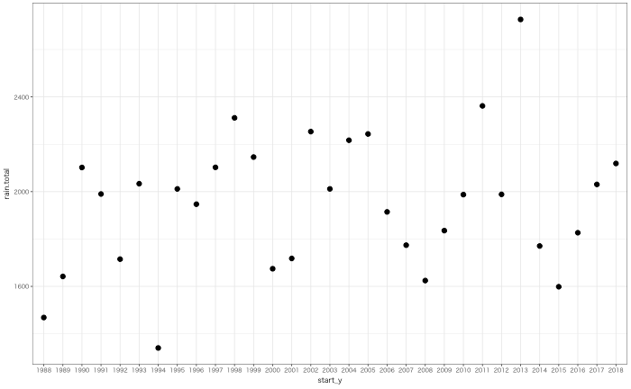

```r
ggplot(data=year_sun_rain_tmpr) + geom_point(mapping = aes(x=start_y, y=rain.total))
```

月ごとに平均する。並べ替える関係で，start_m を factor から integer に変えてる。

```r
month_sun_rain_tmpr <- named_tbl_1 %>% group_by_('start_y', 'start_m') %>% summarise(sun.total = sum(日照時間), rain.total = sum(降水量), tmpr.avr = mean(平均気温), tmpr.day_high = mean(日最高気温), tmpr.day_low = mean(日最低気温)) %>% mutate(start_m = as.integer(as.character(start_m))) %>% arrange(start_y, start_m)
comp_y_m <- function(y,m){
  y_str <- as.character(y)
  m_str <- as.character(m)
  m_str_2 <- padding_date(m_str)
  str_c(y_str,m_str_2,sep='/')
}
month_sun_rain_tmpr %<>% mutate(ym=comp_y_m(start_y,start_m)) %>% glimpse()
```

```
Observations: 371
Variables: 8
$ start_y       <fct> 1988, 1988, 1988, 1988, 1988, 1988, 1988, 1988, 1988, 1988, 1988, 1988, 1989, 1989, 1989, 1989,...
$ start_m       <int> 1, 2, 3, 4, 5, 6, 7, 8, 9, 10, 11, 12, 1, 2, 3, 4, 5, 6, 7, 8, 9, 10, 11, 12, 1, 2, 3, 4, 5, 6,...
$ sun.total     <dbl> 36.1, 57.8, 111.6, 180.4, 181.2, 158.2, 159.5, 221.6, 142.2, 144.9, 87.5, 43.2, 63.2, 63.1, 119...
$ rain.total    <dbl> 192.0, 99.0, 76.0, 94.0, 112.5, 65.0, 94.0, 96.0, 151.5, 173.0, 188.5, 127.0, 123.5, 124.0, 83....
$ tmpr.avr      <dbl> 2.5333333, -0.3333333, 3.6666667, 9.4000000, 13.9666667, 19.4666667, 21.1333333, 26.2666667, 20...
$ tmpr.day_high <dbl> 5.500000, 2.333333, 7.333333, 14.166667, 17.933333, 23.333333, 24.933333, 30.733333, 24.566667,...
$ tmpr.day_low  <dbl> -3.666667e-01, -2.800000e+00, -1.666667e-01, 4.733333e+00, 1.043333e+01, 1.596667e+01, 1.813333...
$ ym            <chr> "1988/01", "1988/02", "1988/03", "1988/04", "1988/05", "1988/06", "1988/07", "1988/08", "1988/0...
```

```r
# month_sun_rain_tmpr
```

グラフにしてみる。

```r
ggplot()+theme_set(theme_bw(base_size = 6,base_family="HiraKakuProN-W3"))
```

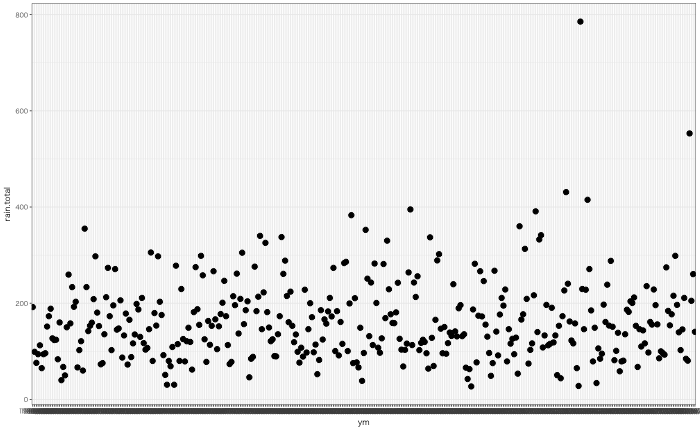

```r
ggplot(data=month_sun_rain_tmpr) + geom_point(mapping = aes(x=ym, y=rain.total))
```

月ごとにまとめて散布図に。

```r
ggplot()+theme_set(theme_bw(base_size = 6,base_family="HiraKakuProN-W3"))
```

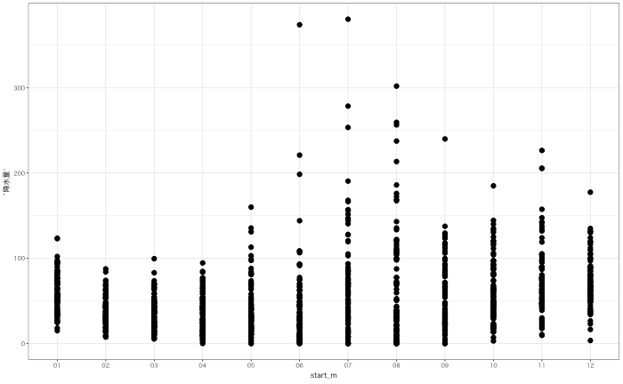

```r
ggplot(data=named_tbl_1) + geom_point(mapping = aes(x=start_m, y=降水量))
```

アレンジ。

```r
ggplot()+theme_set(theme_bw(base_size = 6,base_family="HiraKakuProN-W3"))
```

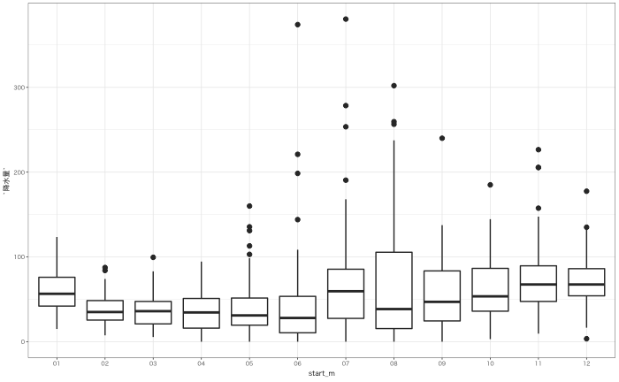

```r
ggplot(data=named_tbl_1) + geom_boxplot(mapping = aes(x=start_m, y=降水量))
```

```r
ggplot()+theme_set(theme_bw(base_size = 6,base_family="HiraKakuProN-W3"))
```

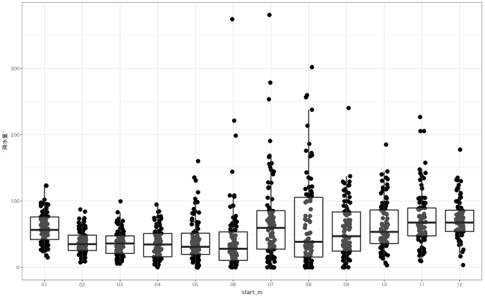

```r
ggplot(data=named_tbl_1, aes(x=start_m, y=降水量)) + geom_jitter(width=0.1) + geom_boxplot(alpha=0.3, outlier.shape = NA)
```

```r
cCyan <- "#00a0e9"
cMagenta <- "#e4007f"
cGreen <- "#009944"
cOrange <- "#f39800"
cLightBlue <- "#0068b7"
qcolours <- c(cCyan,cMagenta,cGreen,cOrange,cLightBlue)
ggplot()+theme_set(theme_bw(base_size = 6,base_family="HiraKakuProN-W3"))
```

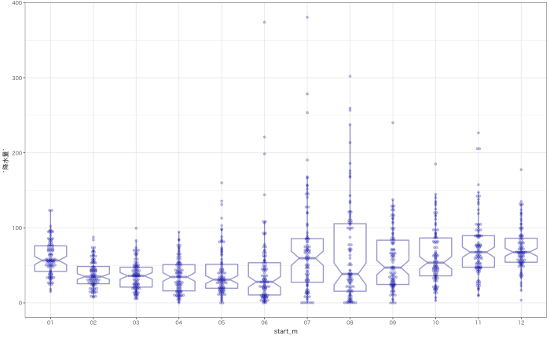

```r
# ggplot(data=named_tbl_1, aes(x=start_m, y=降水量, colour='place')) + geom_dotplot(binwidth=1, dotsize=3, binaxis="y", stackdir="center", na.rm = TRUE, fill = 'blue') + geom_boxplot(alpha=0.3, notch = TRUE, na.rm = TRUE, outlier.shape = NA) + scale_fill_brewer(palette="Spectral") + scale_colour_manual(values = qcolours)
ggplot(data=named_tbl_1, aes(x=start_m, y=降水量)) + geom_boxplot(alpha=0.3, notch = TRUE, na.rm = TRUE, outlier.shape = NA, colour = '#00009966') + scale_fill_brewer(palette="Spectral") + geom_dotplot(binwidth=1, dotsize=3, binaxis="y", stackdir="center", na.rm = TRUE, colour = 'blue', alpha = 0.2)
```

```r
ggplot()+theme_set(theme_bw(base_size = 6,base_family="HiraKakuProN-W3"))
```

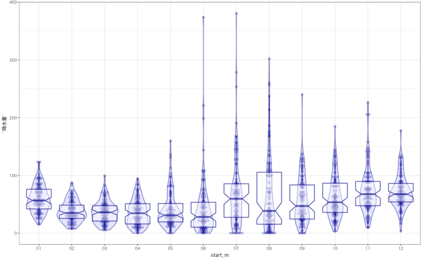

```r
ggplot(data=named_tbl_1, aes(x=start_m, y=降水量, colour='place')) + geom_violin(na.rm = TRUE, colour = '#00009966', fill = 'blue', alpha = 0.1) + geom_dotplot(binwidth=1, dotsize=4, binaxis="y", stackdir="center", na.rm = TRUE, colour = 'blue', alpha = 0.2) + geom_boxplot(alpha=0.4, notch = TRUE, na.rm = TRUE, outlier.shape = NA, colour = '#00009999')
```